# NYS Schools & Poverty: How Community Conditions Relate to Test Performance

Prepared for the NYC Department of Education

Yinuo Zhu

2026-09-21

```r
# ------------------------------------------------------------------
# 缺失值处理：只删除分析所需关键变量缺失的行
# 不用全表 drop_na()，避免因无关列的缺失误删大量有效记录
# ------------------------------------------------------------------
n_before <- nrow(merged)

merged_complete <- merged |>
  drop_na(
    county_name, year, total_enroll,
    per_free_lunch, per_reduced_lunch,
    county_per_poverty, poverty_group,
    math_z, ela_z
  ) |>
  # 固定贫困分组顺序为 low < medium < high（影响所有表格和图的排序）
  mutate(poverty_group = factor(poverty_group,
                                levels = c("low", "medium", "high")))

n_after     <- nrow(merged_complete)
n_dropped   <- n_before - n_after
pct_dropped <- round(n_dropped / n_before * 100, 1)
```

```r
# ------------------------------------------------------------------
# 缺失是否随机？检查被删记录是否集中在特定年份
# 如果某一年缺失率畸高，说明缺失非随机，结论需要更谨慎
# ------------------------------------------------------------------
missing_by_year <- merged |>
  mutate(is_complete = !is.na(math_z) & !is.na(ela_z) &
           !is.na(per_free_lunch) & !is.na(county_per_poverty)) |>
  group_by(year) |>
  summarise(n_total = n(),
            n_dropped = sum(!is_complete),
            pct_dropped = round(mean(!is_complete) * 100, 1),
            .groups = "drop")

max_year_missing <- max(missing_by_year$pct_dropped)
```

```r
# ------------------------------------------------------------------
# 统一的 WSJ 绘图主题
# theme_wsj() 默认隐藏坐标轴标题、字号偏大，这里手动调回可用状态
# ------------------------------------------------------------------
wsj_tweak <- theme_wsj(base_size = 10, color = "brown") +
  theme(
    plot.title      = element_text(size = 15, face = "bold"),
    plot.subtitle   = element_text(size = 10, color = "grey30"),
    axis.title      = element_text(size = 10, face = "plain"),  # 覆盖掉 blank
    axis.title.x    = element_text(margin = margin(t = 8)),
    axis.title.y    = element_text(margin = margin(r = 8)),
    axis.text       = element_text(size = 9),
    strip.text      = element_text(size = 11, face = "bold"),
    legend.position = "bottom",
    legend.title    = element_blank()
  )

# 图表输出目录
dir.create("figures", showWarnings = FALSE)
```

# Executive summary

**Bottom line for policy:** the data supports targeting resources by community poverty level, but does *not* support the claim that expanding lunch access would by itself move test scores.

# 1. Framing the question

## Why is the department asking?

Before touching the data, it is worth asking what decision these questions feed into. A department asking “how does poverty relate to test performance” is usually working toward one of three things: justifying a funding formula that weights by need, identifying schools that are over- or under-performing relative to their community conditions, or evaluating whether an existing program (here, subsidized lunch) is doing what it was meant to do. Those three goals need different analyses, and the third one is the hardest to support with observational county-level data.

## What could answer them

- **Relationship between poverty and scores:** a school-level scatter with a fitted line, plus group means across poverty tertiles.
- **Change over time:** the same group means plotted by year, so a narrowing or widening gap would be visible.
- **Moderation by lunch access:** an interaction model — but only if poverty and lunch participation vary independently enough to be separated.

## What I expected to find, before looking

A clear negative association between poverty and scores (this is one of the most replicated findings in education research), a gap that persists over time, and a lunch-access variable so correlated with poverty that it functions as a proxy for it rather than as an independent lever. The analysis below confirms all three.

# 2. Data and methods

**Why z-scores.** Scale scores are not comparable year-to-year because the state changes tests over time. All performance metrics below are z-scores standardized **within each year** (mean 0, SD 1), so -0.5 always means “half a standard deviation below that year’s statewide average,” regardless of which year the observation comes from.

**Missing data.** Records missing any variable needed for the analysis were dropped. This removed 8,907 of 35,639 school-year records (25%), leaving 26,732 complete cases.

```r
kable(missing_by_year, digits = 1,
      col.names = c("Year", "Records", "Dropped", "% dropped"),
      caption = "Missing-data rate by year — checking whether attrition is concentrated in particular years",
      format.args = list(big.mark = ","))
```

Missing-data rate by year — checking whether attrition is concentrated in particular years

| Year | Records | Dropped | % dropped |
| --- | --- | --- | --- |
| 2,008 | 3,511 | 3,511 | 100.0 |
| 2,009 | 3,528 | 201 | 5.7 |
| 2,010 | 3,573 | 232 | 6.5 |
| 2,011 | 3,584 | 230 | 6.4 |
| 2,012 | 3,559 | 228 | 6.4 |
| 2,013 | 3,553 | 244 | 6.9 |
| 2,014 | 3,581 | 222 | 6.2 |
| 2,015 | 3,581 | 228 | 6.4 |
| 2,016 | 3,600 | 242 | 6.7 |
| 2,017 | 3,569 | 3,569 | 100.0 |

The highest single-year attrition rate is 100%. This is high enough that the affected year(s) should be interpreted with caution — the remaining schools in those years may not be representative.

# 3. Question 1: Does lunch access relate to performance?

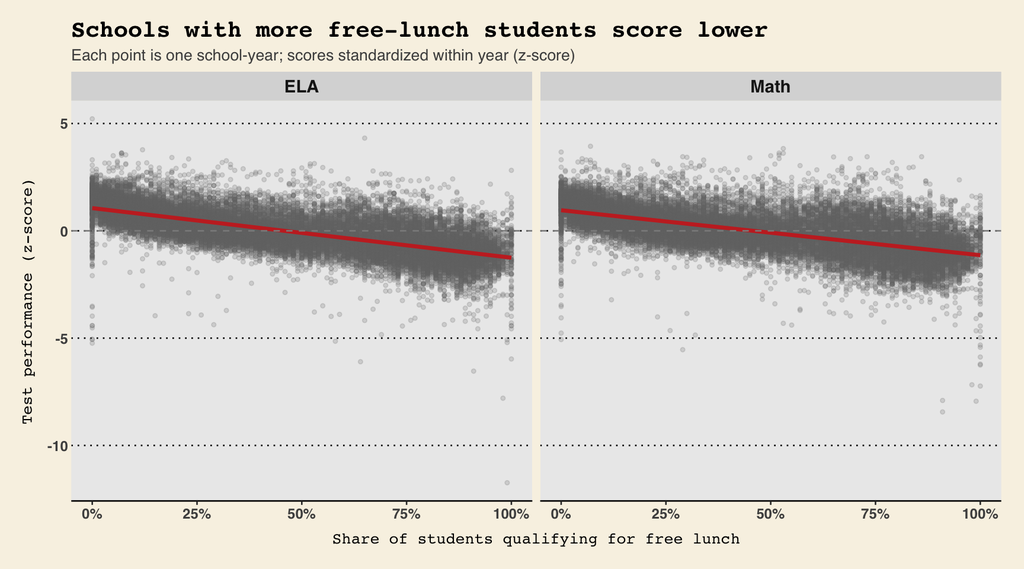

```r
# 学校层面：免费午餐比例 vs 标准化成绩
# pivot_longer 转长格式，便于用 facet 并排对比两个科目
plot1_data <- merged_complete |>
  pivot_longer(cols = c(math_z, ela_z),
               names_to = "subject", values_to = "z_score") |>
  mutate(subject = recode(subject, math_z = "Math", ela_z = "ELA"))

plot1 <- plot1_data |>
  ggplot(aes(x = per_free_lunch, y = z_score)) +
  geom_point(alpha = 0.20, color = "grey45", size = 1) +
  geom_smooth(method = "lm", formula = y ~ x,
              color = "#C72E29", fill = "#C72E29",
              alpha = 0.2, linewidth = 1.2) +
  geom_hline(yintercept = 0, linetype = "dashed", color = "grey55") +
  facet_wrap(~ subject) +
  scale_x_continuous(labels = percent_format(accuracy = 1)) +
  labs(
    title    = "Schools with more free-lunch students score lower",
    subtitle = "Each point is one school-year; scores standardized within year (z-score)",
    x        = "Share of students qualifying for free lunch",
    y        = "Test performance (z-score)"
  ) +
  wsj_tweak

plot1
```

```r
# bg 参数必须显式指定，否则 WSJ 的米色背景在导出时会丢失
ggsave("figures/lunch_vs_performance.png", plot1,
       width = 9, height = 5, dpi = 300, bg = "#f8f2e4")
```

```r
# 拟合线性模型提取斜率
# 斜率单位是"免费午餐比例每增加 1（即 100 个百分点）"，
# 除以 10 换算成"每增加 10 个百分点"，更符合日常解读习惯
fit_math <- lm(math_z ~ per_free_lunch, data = merged_complete)
fit_ela  <- lm(ela_z  ~ per_free_lunch, data = merged_complete)

slope_math_10pp <- round(coef(fit_math)[["per_free_lunch"]] / 10, 3)
slope_ela_10pp  <- round(coef(fit_ela)[["per_free_lunch"]]  / 10, 3)

r2_math <- round(summary(fit_math)$r.squared, 3)
r2_ela  <- round(summary(fit_ela)$r.squared,  3)

cor_math <- round(cor(merged_complete$per_free_lunch, merged_complete$math_z), 2)
cor_ela  <- round(cor(merged_complete$per_free_lunch, merged_complete$ela_z),  2)
```

```r
bind_rows(
  tidy(fit_math) |> mutate(outcome = "Math"),
  tidy(fit_ela)  |> mutate(outcome = "ELA")
) |>
  filter(term == "per_free_lunch") |>
  select(outcome, estimate, std.error, statistic, p.value) |>
  mutate(r_squared = c(r2_math, r2_ela)) |>
  kable(digits = 3,
        col.names = c("Outcome", "Slope", "Std. error", "t", "p", "R²"),
        caption = "Free-lunch share as a predictor of within-year z-score")
```

Free-lunch share as a predictor of within-year z-score

| Outcome | Slope | Std. error | t | p | R² |
| --- | --- | --- | --- | --- | --- |
| Math | -2.096 | 0.016 | -129.784 | 0 | 0.387 |
| ELA | -2.311 | 0.015 | -154.613 | 0 | 0.472 |

**Takeaway:** Each 10-percentage-point increase in a school’s free-lunch share is associated with a change of about -0.21 standard deviations in math and -0.231 in ELA. The correlations are -0.62 and -0.69 respectively, so the relationship runs in the same direction and at similar strength in both subjects. Free-lunch share alone explains 38.7% of the variance in math scores.

**How to read this:** free-lunch share is best understood here as a *measure* of student poverty, not as an intervention. A finding that high-free-lunch schools score lower is a finding about student poverty, not evidence that the lunch program depresses scores.

# 4. Question 2: Performance across poverty groups

```r
# 按县的贫困分组汇总标准化成绩
poverty_group_summary <- merged_complete |>
  group_by(poverty_group) |>
  summarise(
    n_school_years = n(),                   # 注意：学校-年记录数，不是县-年
    n_counties     = n_distinct(county_name),
    mean_math_z    = mean(math_z),
    mean_ela_z     = mean(ela_z),
    sd_math_z      = sd(math_z),            # 组内离散度：高贫困组内部差异更大吗？
    .groups        = "drop"
  )

kable(poverty_group_summary, digits = 2,
      col.names = c("Poverty group", "School-years", "Counties",
                    "Mean math (z)", "Mean ELA (z)", "SD math (z)"),
      caption = "Mean standardized scores by county poverty group",
      format.args = list(big.mark = ","))
```

Mean standardized scores by county poverty group

| Poverty group | School-years | Counties | Mean math (z) | Mean ELA (z) | SD math (z) |
| --- | --- | --- | --- | --- | --- |
| low | 8,282 | 30 | 0.34 | 0.41 | 0.90 |
| medium | 6,690 | 41 | -0.02 | -0.02 | 0.96 |
| high | 11,760 | 30 | -0.22 | -0.27 | 1.02 |

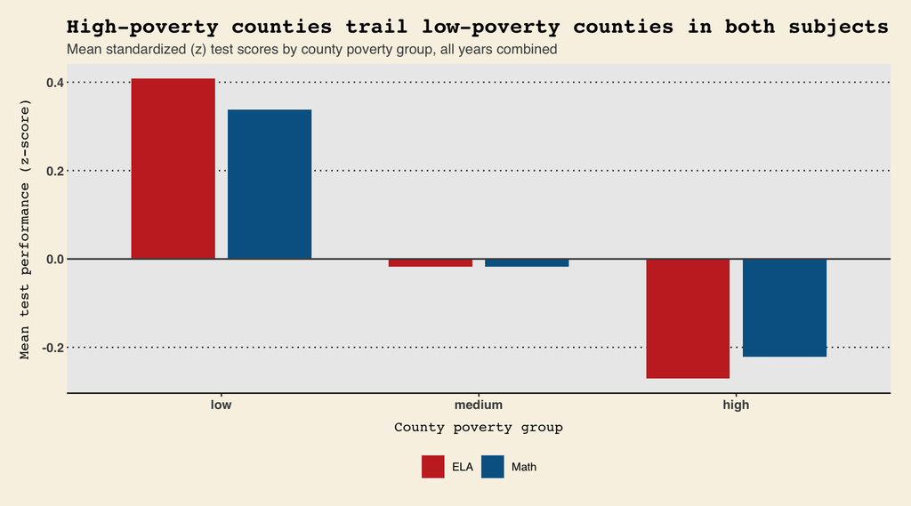

```r
plot2_data <- poverty_group_summary |>
  select(poverty_group, mean_math_z, mean_ela_z) |>
  pivot_longer(-poverty_group, names_to = "subject", values_to = "mean_z") |>
  mutate(subject = recode(subject, mean_math_z = "Math", mean_ela_z = "ELA"))

plot2 <- plot2_data |>
  ggplot(aes(x = poverty_group, y = mean_z, fill = subject)) +
  geom_col(position = position_dodge(width = 0.75), width = 0.65) +
  geom_hline(yintercept = 0, color = "grey30", linewidth = 0.6) +
  scale_fill_wsj(palette = "colors6") +
  labs(
    title    = "High-poverty counties trail low-poverty counties in both subjects",
    subtitle = "Mean standardized (z) test scores by county poverty group, all years combined",
    x        = "County poverty group",
    y        = "Mean test performance (z-score)"
  ) +
  wsj_tweak

plot2
```

```r
ggsave("figures/poverty_group_performance.png", plot2,
       width = 8, height = 5, dpi = 300, bg = "#f8f2e4")
```

```r
gap <- poverty_group_summary |>
  filter(poverty_group %in% c("low", "high")) |>
  select(poverty_group, mean_math_z, mean_ela_z) |>
  pivot_longer(-poverty_group) |>
  pivot_wider(names_from = poverty_group, values_from = value) |>
  mutate(gap = low - high)

gap_math <- round(gap$gap[gap$name == "mean_math_z"], 2)
gap_ela  <- round(gap$gap[gap$name == "mean_ela_z"],  2)
```

**Takeaway:** Students in high-poverty counties score about 0.56 standard deviations below those in low-poverty counties in math, and 0.68 standard deviations below in ELA. The gap is somewhat larger in ELA than in math. Because these are within-year z-scores, each figure can be read directly as a position in that year’s statewide distribution.

# 5. Question 3: Has the relationship changed over time?

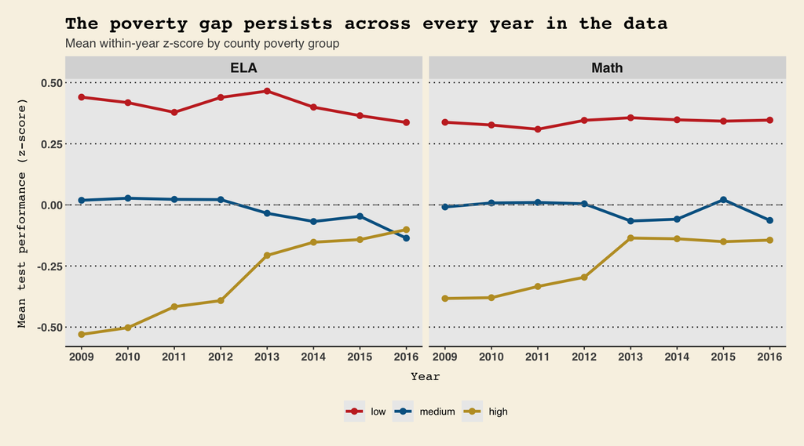

```r
# 按 年份 × 贫困分组 求平均，观察差距是收窄还是扩大
trend_data <- merged_complete |>
  group_by(year, poverty_group) |>
  summarise(mean_math_z = mean(math_z),
            mean_ela_z  = mean(ela_z),
            .groups     = "drop") |>
  pivot_longer(c(mean_math_z, mean_ela_z),
               names_to = "subject", values_to = "mean_z") |>
  mutate(subject = recode(subject, mean_math_z = "Math", mean_ela_z = "ELA"))

plot3 <- trend_data |>
  ggplot(aes(x = year, y = mean_z, color = poverty_group)) +
  geom_line(linewidth = 1.1) +
  geom_point(size = 2) +
  geom_hline(yintercept = 0, linetype = "dashed", color = "grey55") +
  facet_wrap(~ subject) +
  scale_x_continuous(breaks = unique(trend_data$year)) +
  scale_color_wsj(palette = "colors6") +
  labs(
    title    = "The poverty gap persists across every year in the data",
    subtitle = "Mean within-year z-score by county poverty group",
    x        = "Year",
    y        = "Mean test performance (z-score)"
  ) +
  wsj_tweak

plot3
```

```r
ggsave("figures/gap_over_time.png", plot3,
       width = 9, height = 5, dpi = 300, bg = "#f8f2e4")
```

```r
# 每年 低-高 贫困组的数学成绩差距
gap_by_year <- merged_complete |>
  filter(poverty_group %in% c("low", "high")) |>
  group_by(year, poverty_group) |>
  summarise(mean_math_z = mean(math_z), .groups = "drop") |>
  pivot_wider(names_from = poverty_group, values_from = mean_math_z) |>
  mutate(gap = low - high)

first_year <- min(gap_by_year$year)
last_year  <- max(gap_by_year$year)
gap_first  <- round(gap_by_year$gap[gap_by_year$year == first_year], 2)
gap_last   <- round(gap_by_year$gap[gap_by_year$year == last_year],  2)

# 用线性趋势检验差距是否显著变化，比只比较首尾两年更稳健
# 首尾两年可能恰好是异常年份，趋势线用上了全部年份的信息
gap_trend <- lm(gap ~ year, data = gap_by_year)
gap_trend_slope <- round(coef(gap_trend)[["year"]], 4)
gap_trend_p     <- round(summary(gap_trend)$coefficients["year", "Pr(>|t|)"], 3)
```

```r
kable(gap_by_year, digits = 2,
      col.names = c("Year", "Low poverty (z)", "High poverty (z)", "Gap"),
      caption = "Math performance gap between low- and high-poverty counties, by year")
```

Math performance gap between low- and high-poverty counties, by year

| Year | Low poverty (z) | High poverty (z) | Gap |
| --- | --- | --- | --- |
| 2009 | 0.34 | -0.38 | 0.72 |
| 2010 | 0.33 | -0.38 | 0.71 |
| 2011 | 0.31 | -0.33 | 0.64 |
| 2012 | 0.35 | -0.30 | 0.64 |
| 2013 | 0.36 | -0.14 | 0.49 |
| 2014 | 0.35 | -0.14 | 0.49 |
| 2015 | 0.34 | -0.15 | 0.49 |
| 2016 | 0.35 | -0.14 | 0.49 |

**Takeaway:** In 2009 the math gap between low- and high-poverty counties was 0.72 standard deviations; by 2016 it was 0.49. Fitting a trend across all years gives a slope of -0.0392 per year (p = 0.001), so the gap narrowed at a statistically detectable rate, though slowly. No year in the data shows high-poverty counties reaching the statewide average, which points to a structural pattern rather than year-specific noise.

# 6. Question 4: Does lunch access moderate the relationship?

This is the department’s hardest question, and the honest answer is that this data cannot settle it. The section below shows the analysis *and* why its result should not be over-read.

```r
# ------------------------------------------------------------------
# 做交互项之前必须先查共线性
# 如果贫困率和免费午餐比例高度相关，交互项系数会极不稳定，
# 标准误膨胀，符号甚至可能翻转——此时任何解读都不可靠
# ------------------------------------------------------------------
cor_pov_lunch <- round(cor(merged_complete$county_per_poverty,
                           merged_complete$per_free_lunch), 2)
cor_pov_lunch
```

```
## [1] 0.63
```

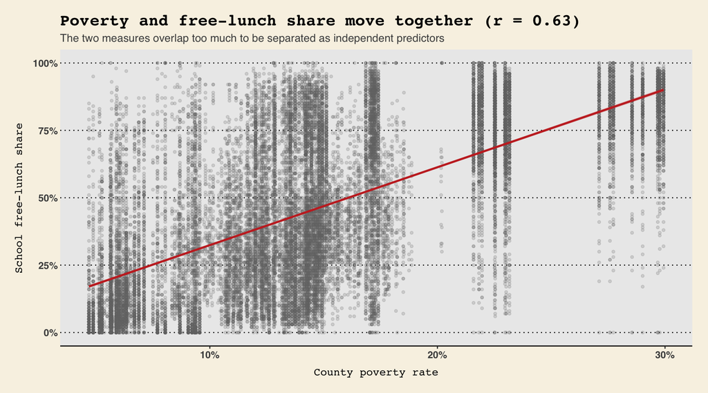

```r
plot4 <- merged_complete |>
  ggplot(aes(x = county_per_poverty, y = per_free_lunch)) +
  geom_point(alpha = 0.20, color = "grey45", size = 1) +
  geom_smooth(method = "lm", formula = y ~ x,
              color = "#C72E29", fill = "#C72E29", alpha = 0.2) +
  scale_x_continuous(labels = percent_format(accuracy = 1)) +
  scale_y_continuous(labels = percent_format(accuracy = 1)) +
  labs(
    title    = paste0("Poverty and free-lunch share move together (r = ",
                      cor_pov_lunch, ")"),
    subtitle = "The two measures overlap too much to be separated as independent predictors",
    x        = "County poverty rate",
    y        = "School free-lunch share"
  ) +
  wsj_tweak

plot4
```

```r
ggsave("figures/collinearity.png", plot4,
       width = 8, height = 5, dpi = 300, bg = "#f8f2e4")
```

```r
# ------------------------------------------------------------------
# 交互项模型：中心化后再交乘
# 不中心化的话，主效应系数代表"另一变量=0 时的效应"，
# 而"贫困率=0"在数据中根本不存在，系数无法解读
# ------------------------------------------------------------------
model_data <- merged_complete |>
  mutate(
    poverty_c = county_per_poverty - mean(county_per_poverty),
    lunch_c   = per_free_lunch    - mean(per_free_lunch)
  )

fit_main        <- lm(math_z ~ poverty_c + lunch_c, data = model_data)
fit_interaction <- lm(math_z ~ poverty_c * lunch_c, data = model_data)

tidy(fit_interaction) |>
  kable(digits = 3,
        col.names = c("Term", "Estimate", "Std. error", "t", "p"),
        caption = "Interaction model: does free-lunch share change the poverty slope?")
```

Interaction model: does free-lunch share change the poverty slope?

| Term | Estimate | Std. error | t | p |
| --- | --- | --- | --- | --- |
| (Intercept) | -0.016 | 0.006 | -2.776 | 0.006 |
| poverty_c | 2.076 | 0.101 | 20.589 | 0.000 |
| lunch_c | -2.391 | 0.021 | -115.165 | 0.000 |
| poverty_c:lunch_c | 1.526 | 0.268 | 5.690 | 0.000 |

```r
# 用 F 检验比较有无交互项的两个模型，判断交互项是否带来解释力提升
model_comparison <- anova(fit_main, fit_interaction)
interaction_p <- round(model_comparison$`Pr(>F)`[2], 3)

r2_main        <- round(summary(fit_main)$r.squared, 3)
r2_interaction <- round(summary(fit_interaction)$r.squared, 3)
r2_delta       <- round(r2_interaction - r2_main, 4)
```

**Takeaway:** The interaction term is statistically significant (p = 0), and adding it raises R² by only 0 (from 0.4 to 0.4).

**Why this is not an answer to the department’s question.** County poverty and school free-lunch share correlate at 0.63. When two predictors overlap this heavily, the model cannot attribute variance between them reliably: standard errors inflate, coefficients become unstable, and an interaction term built from them is especially fragile. A significant interaction here would be as likely to reflect collinearity artifacts as a real moderating effect, and a null result does not establish that no moderation exists.

**What would actually answer it.** Comparing schools at *similar* poverty levels that differ in lunch participation — for example, schools that adopted universal free meals versus otherwise-similar schools that did not, with data from before and after adoption. That is a program-evaluation design, and it needs participation data that varies independently of community poverty. This dataset does not contain that variation.

# 7. County profiles

```r
county_summary <- merged_complete |>
  group_by(county_name) |>
  summarise(
    years_covered          = n_distinct(year),
    total_enrollment       = sum(total_enroll),
    per_free_lunch_mean    = mean(per_free_lunch),
    per_reduced_lunch_mean = mean(per_reduced_lunch),
    per_poverty_mean       = mean(county_per_poverty),
    .groups                = "drop"
  ) |>
  arrange(desc(per_poverty_mean))

kable(county_summary, digits = 3,
      col.names = c("County", "Years", "Total enrollment",
                    "Free lunch", "Reduced lunch", "Poverty rate"),
      caption = "County profiles, averaged across available years",
      format.args = list(big.mark = ","))
```

County profiles, averaged across available years

| County | Years | Total enrollment | Free lunch | Reduced lunch | Poverty rate |
| --- | --- | --- | --- | --- | --- |
| BRONX | 8 | 1,284,899 | 0.807 | 0.055 | 0.287 |
| KINGS | 8 | 1,820,270 | 0.733 | 0.063 | 0.225 |
| MONTGOMERY | 8 | 39,656 | 0.461 | 0.074 | 0.177 |
| TOMPKINS | 8 | 62,804 | 0.341 | 0.072 | 0.175 |
| CHAUTAUQUA | 8 | 101,699 | 0.466 | 0.085 | 0.175 |
| NEW YORK | 8 | 817,590 | 0.647 | 0.057 | 0.172 |
| CATTARAUGUS | 8 | 71,433 | 0.402 | 0.104 | 0.164 |
| SULLIVAN | 8 | 50,586 | 0.411 | 0.082 | 0.164 |
| SAINT LAWRENCE | 8 | 85,741 | 0.422 | 0.104 | 0.163 |
| FULTON | 8 | 40,659 | 0.436 | 0.099 | 0.161 |
| OSWEGO | 8 | 106,347 | 0.418 | 0.094 | 0.161 |
| BROOME | 8 | 147,450 | 0.389 | 0.077 | 0.159 |
| FRANKLIN | 8 | 36,609 | 0.438 | 0.108 | 0.157 |
| ALLEGANY | 8 | 44,973 | 0.405 | 0.114 | 0.151 |
| ONEIDA | 8 | 182,115 | 0.408 | 0.084 | 0.149 |
| CHEMUNG | 8 | 61,490 | 0.401 | 0.070 | 0.149 |
| STEUBEN | 8 | 80,921 | 0.384 | 0.121 | 0.147 |
| OTSEGO | 8 | 46,559 | 0.327 | 0.112 | 0.147 |
| CHENANGO | 8 | 35,741 | 0.441 | 0.118 | 0.145 |
| JEFFERSON | 8 | 109,233 | 0.337 | 0.132 | 0.142 |
| YATES | 8 | 11,579 | 0.458 | 0.097 | 0.141 |
| MONROE | 8 | 561,377 | 0.408 | 0.059 | 0.140 |
| QUEENS | 8 | 1,592,148 | 0.617 | 0.100 | 0.140 |
| ERIE | 8 | 711,485 | 0.404 | 0.068 | 0.140 |
| ONONDAGA | 8 | 371,159 | 0.378 | 0.062 | 0.139 |
| DELAWARE | 8 | 37,038 | 0.394 | 0.132 | 0.139 |
| HERKIMER | 8 | 50,817 | 0.388 | 0.108 | 0.138 |
| LEWIS | 8 | 24,602 | 0.373 | 0.141 | 0.137 |
| CORTLAND | 8 | 26,689 | 0.401 | 0.100 | 0.134 |
| CLINTON | 8 | 55,527 | 0.351 | 0.090 | 0.132 |
| NIAGARA | 8 | 153,738 | 0.398 | 0.087 | 0.129 |
| ORLEANS | 8 | 30,412 | 0.405 | 0.099 | 0.128 |
| ROCKLAND | 8 | 206,050 | 0.266 | 0.049 | 0.127 |
| GREENE | 8 | 35,169 | 0.328 | 0.079 | 0.127 |
| ALBANY | 8 | 207,383 | 0.370 | 0.058 | 0.123 |
| GENESEE | 8 | 36,285 | 0.322 | 0.098 | 0.120 |
| WASHINGTON | 8 | 43,706 | 0.341 | 0.093 | 0.119 |
| LIVINGSTON | 8 | 36,517 | 0.291 | 0.074 | 0.118 |
| ULSTER | 8 | 119,629 | 0.333 | 0.079 | 0.118 |
| RENSSELAER | 8 | 106,644 | 0.334 | 0.066 | 0.118 |
| ORANGE | 8 | 307,278 | 0.306 | 0.079 | 0.117 |
| SCHENECTADY | 8 | 114,008 | 0.387 | 0.061 | 0.116 |
| SENECA | 8 | 17,760 | 0.305 | 0.098 | 0.116 |
| CAYUGA | 8 | 46,201 | 0.345 | 0.073 | 0.115 |
| RICHMOND | 8 | 342,871 | 0.498 | 0.086 | 0.114 |
| WAYNE | 8 | 67,797 | 0.341 | 0.103 | 0.113 |
| SCHOHARIE | 8 | 24,170 | 0.337 | 0.119 | 0.112 |
| ESSEX | 8 | 23,929 | 0.324 | 0.118 | 0.110 |
| WARREN | 8 | 50,651 | 0.309 | 0.075 | 0.108 |
| SCHUYLER | 8 | 7,693 | 0.347 | 0.080 | 0.107 |
| HAMILTON | 8 | 3,995 | 0.196 | 0.100 | 0.103 |
| MADISON | 8 | 49,836 | 0.336 | 0.088 | 0.100 |
| COLUMBIA | 8 | 33,123 | 0.279 | 0.089 | 0.098 |
| WYOMING | 8 | 18,493 | 0.290 | 0.101 | 0.096 |
| TIOGA | 8 | 40,374 | 0.389 | 0.104 | 0.096 |
| ONTARIO | 8 | 66,128 | 0.282 | 0.077 | 0.092 |
| WESTCHESTER | 8 | 778,738 | 0.297 | 0.051 | 0.089 |
| DUTCHESS | 8 | 192,937 | 0.266 | 0.071 | 0.083 |
| SARATOGA | 8 | 181,419 | 0.172 | 0.046 | 0.064 |
| SUFFOLK | 8 | 1,199,603 | 0.222 | 0.053 | 0.062 |
| PUTNAM | 8 | 77,565 | 0.102 | 0.033 | 0.058 |
| NASSAU | 8 | 1,003,378 | 0.173 | 0.044 | 0.056 |

# 8. Top 5 vs Bottom 5 counties by poverty

```r
# 贫困率最高和最低的各 5 个县
extreme_counties <- bind_rows(
  county_summary |> slice_max(per_poverty_mean, n = 5) |>
    mutate(extreme_group = "Top 5 (highest poverty)"),
  county_summary |> slice_min(per_poverty_mean, n = 5) |>
    mutate(extreme_group = "Bottom 5 (lowest poverty)")
)

top_bottom_summary <- merged_complete |>
  filter(county_name %in% extreme_counties$county_name) |>
  # 先逐行相加再求均值，比"两个均值相加"更准确（两列缺失模式可能不同）
  mutate(free_reduced = per_free_lunch + per_reduced_lunch) |>
  group_by(county_name) |>
  summarise(
    per_poverty      = mean(county_per_poverty),
    per_free_reduced = mean(free_reduced),
    mean_reading     = mean(mean_ela_score, na.rm = TRUE),
    mean_math        = mean(mean_math_score, na.rm = TRUE),
    mean_reading_z   = mean(ela_z),
    mean_math_z      = mean(math_z),
    .groups          = "drop"
  ) |>
  left_join(select(extreme_counties, county_name, extreme_group),
            by = "county_name") |>
  arrange(desc(per_poverty))

kable(top_bottom_summary, digits = 2,
      col.names = c("County", "Poverty rate", "Free + reduced lunch",
                    "Reading (raw)", "Math (raw)",
                    "Reading (z)", "Math (z)", "Group"),
      caption = "Five highest- and five lowest-poverty counties")
```

Five highest- and five lowest-poverty counties

| County | Poverty rate | Free + reduced lunch | Reading (raw) | Math (raw) | Reading (z) | Math (z) | Group |
| --- | --- | --- | --- | --- | --- | --- | --- |
| BRONX | 0.29 | 0.86 | 464.35 | 472.65 | -0.77 | -0.70 | Top 5 (highest poverty) |
| KINGS | 0.22 | 0.80 | 469.82 | 479.30 | -0.28 | -0.23 | Top 5 (highest poverty) |
| MONTGOMERY | 0.18 | 0.54 | 480.37 | 490.96 | -0.48 | -0.40 | Top 5 (highest poverty) |
| TOMPKINS | 0.18 | 0.41 | 483.58 | 493.23 | 0.11 | 0.03 | Top 5 (highest poverty) |
| CHAUTAUQUA | 0.17 | 0.55 | 484.49 | 495.58 | -0.23 | -0.16 | Top 5 (highest poverty) |
| DUTCHESS | 0.08 | 0.34 | 492.89 | 501.08 | 0.10 | -0.07 | Bottom 5 (lowest poverty) |
| SARATOGA | 0.06 | 0.22 | 492.83 | 503.55 | 0.63 | 0.51 | Bottom 5 (lowest poverty) |
| SUFFOLK | 0.06 | 0.28 | 490.61 | 501.25 | 0.38 | 0.32 | Bottom 5 (lowest poverty) |
| PUTNAM | 0.06 | 0.14 | 504.33 | 516.48 | 0.66 | 0.61 | Bottom 5 (lowest poverty) |
| NASSAU | 0.06 | 0.22 | 497.17 | 509.33 | 0.88 | 0.81 | Bottom 5 (lowest poverty) |

```r
extreme_gap <- top_bottom_summary |>
  group_by(extreme_group) |>
  summarise(math_raw = mean(mean_math), math_z = mean(mean_math_z),
            .groups = "drop")

raw_hi <- round(extreme_gap$math_raw[extreme_gap$extreme_group ==
                                       "Top 5 (highest poverty)"], 1)
raw_lo <- round(extreme_gap$math_raw[extreme_gap$extreme_group ==
                                       "Bottom 5 (lowest poverty)"], 1)
z_hi   <- round(extreme_gap$math_z[extreme_gap$extreme_group ==
                                     "Top 5 (highest poverty)"], 2)
z_lo   <- round(extreme_gap$math_z[extreme_gap$extreme_group ==
                                     "Bottom 5 (lowest poverty)"], 2)
```

**Takeaway:** The five highest-poverty counties average a raw math scale score of 486.3 versus 506.3 in the five lowest-poverty counties. Because tests change between years, the raw gap mixes real differences with test-form differences; the within-year z-score comparison — -0.29 versus 0.44 — is the figure to cite. Free and reduced lunch participation tracks the poverty ranking closely, which is expected given that eligibility is itself income-based.

# 9. What this analysis does and does not show

**Associations, not causes.** County poverty, free-lunch eligibility, and test scores all move together, but this data cannot separate family income from school funding, teacher experience, neighborhood conditions, or differences in which students sit the test. Nothing here identifies a causal mechanism.

**The ecological inference problem.** Poverty is measured at the county level while performance is measured at the school level. A county-level association does not tell us that the individual low-income students within those schools are the ones scoring lower — that inference requires student-level data, which this dataset does not have.

**Coarse geography.** Within-county variation between neighborhoods is very likely larger than the between-county differences shown here. A county-level poverty measure averages over exactly the variation a targeting policy would want to see.

**Missing data.** 25% of records were dropped. The by-year table in Section 2 shows attrition is uneven across years, so year-to-year comparisons should be treated cautiously, but attrition by county was not examined and could still bias county comparisons.

## Recommendations

1. **Use community poverty as a targeting variable, not as an explanation.** The relationship is strong and stable enough to justify need-weighted resource allocation. It is not strong enough to tell you *what* to fund.
2. **Do not treat lunch participation as a lever based on this analysis.** Section 6 shows the measure is too entangled with poverty to isolate. Evaluating the lunch program needs a before/after design with a comparison group.
3. **Move to school- or student-level poverty data if the goal is targeting.** County averages will systematically under-serve poor schools in wealthy counties and over-serve wealthy schools in poor counties.

# 10. Methods recap